# Regenerative Tissue Innovations | Organogenesis

[video not shown]

[figure not shown]

[figure not shown]

The only FDA-approved skin substitute with bioactive living cells to close DFUs and VLUs faster.<sup>1-8</sup>

## ONLY APLIGRAF<sup>®</sup> HAS FDA-REVIEWED RCTs RESULTING IN FDA APPROVAL TO HEAL DFUs AND VLUs

### DFU RCT

Randomized, controlled trial

208 patients

24 US clinical sites

#### APLIGRAF HEALED MORE DFUs FASTER

[figure not shown]

25

days  
faster median time to wound closure 65 vs 90 days (P=0.0026)

#### HEALING DEMANDS PROOF:

#### APLIGRAF IS BACKED BY PMA-LEVEL EVIDENCE

- Well-designed RCTs are required to obtain FDA approval via PMA regulatory pathway
- Only products approved via PMA regulatory pathway are required to demonstrate clinical effectiveness
- Products supported by both RCTs and real-world evidence provide reliable data, balancing controlled efficacy with real-world performance

## ONLY APLIGRAF<sup>®</sup> HAS FDA-REVIEWED RCTs RESULTING IN FDA APPROVAL TO HEAL DFUs AND VLUs

#### LOWER RATES OF OSTEOMYELITIS AND AMPUTATION WITH APLIGRAF<sup>®</sup>

[figure not shown]

*This study was not designed to determine the incidence of amputations or osteomyelitis.  
These data were acquired through evaluation of clinical trial adverse events.

## ONLY APLIGRAF<sup>®</sup> HAS FDA-REVIEWED RCTs RESULTING IN FDA APPROVAL TO HEAL DFUs AND VLUs

### VLU RCT

Randomized, controlled trial

275 patients

15 US clinical sites

#### APLIGRAF HEALED MORE VLUs FASTER

[figure not shown]

85

days  
faster median time to wound closure 99 vs 184 days (P=0.0074)

## APLIGRAF IS 100% COVERED

Reliable, consistent coverage for patients, regardless of their insurance*

100%

of commercial medical policies cover Apligraf treatment for DFUs and VLUs<sup>1</sup>

100%

of Medicare contractors cover Apligraf treatment for DFUs and VLUs<sup>1</sup>

| Major insurers (sample list) | VLU coverage | DFU coverage |
| --- | --- | --- |
| Aetna | ✓ | ✓ |
| Anthem | ✓ | ✓ |
| BCBS Federal Employee Program | ✓ | ✓ |
| BCBS Highmark | ✓ | ✓ |
| Cigna | ✓ | ✓ |
| Excellus | ✓ | ✓ |
| Humana | ✓ | ✓ |
| Medica | ✓ | ✓ |
| UnitedHealthcare | ✓ | ✓ |

* The coverage information provided shall not be construed as a statement, promise, or guarantee that reimbursement will be received.  
Reimbursement requirements are subject to change at any time. Check with your local payer regularly.

[figure not shown]

[output not shown]

[video not shown]

## Apligraf continues to lead with a comprehensive portfolio of evidence and a foundation of trust built with clinicians and patients for over 20 years.

**References:** **1.** Apligraf [package insert]. Canton, MA: Organogenesis Inc; 2017. **2.** Veves A, et al. Diabetes Care. 2001;24(2):290-295. **3.** Data on file. Organogenesis Inc. **4.** Food and Drug Administration. https://www.fda.gov/medical-devices/premarket-submissions-selecting-and-preparing-correct-submission/premarket-approval-pma. Updated May 16, 2019. Accessed January 6, 2026. **5.** Food and Drug Administration. https://www.fda.gov/medical-devices/premarket-approval-pma/pma-clinical-studies. Updated February 17, 2023. Accessed January 6, 2026. **6.** Falanga V, et al. Arch Dermatol. 1998;134(3): 293-300. **7.** Marston WA, et al. Wound Repair Regen. 2014;22(3):334-340. **8.** Treadwell T, et al. Adv Wound Care. 2018;7(3):69-76. **9.** Sabolinski ML, et al. J Comp Eff Res. 2018;7(8):797-805. **10.** Kirsner RS, et al. Wound Repair Regen. 2015;23(5):737-744. **11.** Milstone LM, et al. Wounds. 2000;12(5 suppl A):12A-19A. **12.** Falanga V, et al. J Invest Dermatol. 2002;119(3):653-660. **13.** Schmid P. Wounds. 2000;12(5 suppl A):4A-11A. **14.** Carlson M, et al. Tissue Eng Part A. 2011;17(3-4):487-493. **15.** Wojtowicz AM, et al. Wound Rep Regen. 2014;22(2):246-255. **16.** Data on file. AP_DR-0004. Organogenesis Inc. **17.** Stone RC, et al. Sci Transl Med. 2017;9(371):eaaf8611. **18.** Brem H, et al. Surg Technol Int. 2003;11:23-31. **19.** Stone RC, et al. Wound Repair Regen. 2020;28(2):164-176.

**Discover Our New Rhode Island Facility – Pioneering the Future of Biomedicine.** [LEARN MORE](https://www.organo-ri.com)

[video not shown]

[figure not shown]

Secure online bill pay and invoice management solution.

[Access Orgopay](https://orgopay.organo.com)

## FUELED BY SCIENCE. POWERED BY LIFE.

From advanced wound care through surgery and sports medicine, we are committed to empowering healing by confidently and reliably delivering clinicians the range of regenerative tissue innovations along with the services they need.

EXPLORE  
ADVANCED WOUND CARE

EXPLORE  
SURGICAL & SPORTS MEDICINE

## GROWING OUR FUTURE IN RHODE ISLAND

Our new state-of-the-art facility in Smithfield strengthens our legacy in regenerative medicine and supports our leading burn and wound care products.

[LEARN MORE](https://www.organo-ri.com)

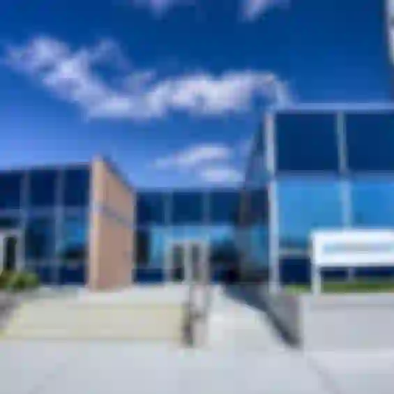

## NEWS & EVENTS

1. ANNOUNCEMENTS

05. 20. 2025

Smithfield, R.I.

#### Organogenesis Unveils Plans for New Biomanufacturing Facility in Smithfield, Rhode Island

Organogenesis Smithfield will add manufacturing, R&D and logistics capabilities supporting existing and planned products designed to advance innovation and regenerative solutions

**READ MORE**

### PATIENT & PROVIDER RESOURCES

Our Circle of Care program provides the highest level of support, helping both patients and healthcare professionals navigate every step of the healing journey.

GET RESOURCES

### RESOURCES

Our teams of reimbursement and regulatory specialists help fulfill our commitment to providing the most advanced regenerative solutions available.

SEE RESOURCES

## QUESTIONS?

Talk to a local Organogenesis specialist today to learn more about our innovative solutions.